# Assignment 2

Shayla Nikzad

12/6/2020

## Load packages

```r
library(tidyverse)
library(sf)
library(tigris)
library(leaflet)
library(censusapi)

Sys.setenv(CENSUS_KEY="b1f6bae8291cffb092a4d2ad892d430db36d538f")

acs_vars_2018_5yr <-
  listCensusMetadata(
    name = "2018/acs/acs5",
    type = "variables"
  )
```

## Part 1: Fetch Data

```r
census_race_labels <-
  c(
    "White Alone",
    "Black or African American",
    "American Indian and Alaska Native Alone",
    "Asian Alone",
    "Native Hawaiian and Other Pacific Islander Alone)",
    "Some Other Race Alone",
    "Two or More Races"
  )

education_race <-
  1:7 %>%
  map_dfr(function(x){
    getCensus(
      name = "acs/acs5",
      vintage = 2018,
      region = "county:097",
      regionin = "state:06",
      vars = paste0("group(C15002",LETTERS[x],")")
    ) %>%
      select(!c(GEO_ID,state,NAME) & !ends_with(c("EA","MA","M"))) %>%
      pivot_longer(
        ends_with("E"),
        names_to = "variable",
        values_to = "estimate"
      ) %>%
      left_join(
        acs_vars_2018_5yr %>%
          select(name, label),
        by = c("variable" = "name")
      ) %>%
      select(-variable) %>%
      separate(
        label,
        into = c(NA,NA,NA, "attainment"),
        sep = "!!"
      ) %>%
      filter(!is.na(attainment)) %>%
      mutate(race = census_race_labels[x])
  })

education_race <- select(education_race, !c(county))
```

## Part 1: Create plots

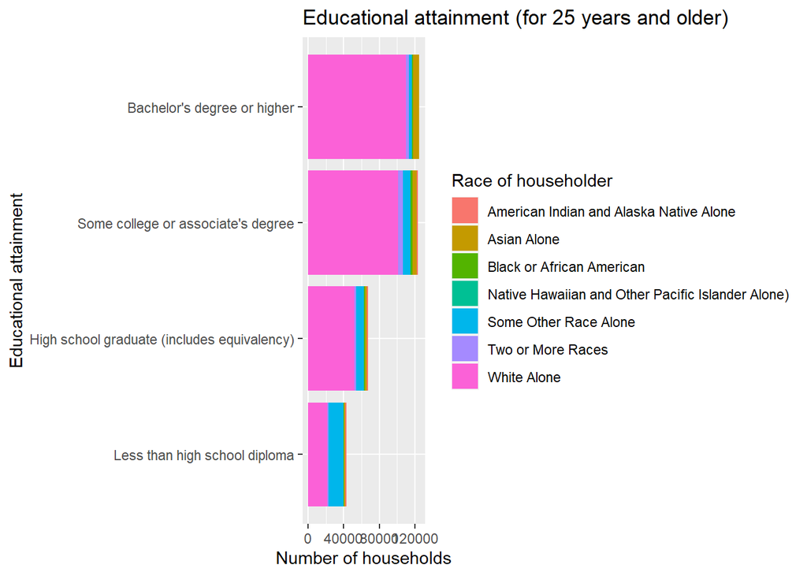

```r
#Stacked bar graph
education_race %>%
  group_by(attainment, race) %>%
  summarize(estimate = sum(estimate)) %>%
  ggplot() +
  geom_bar(
    aes(
      x = attainment %>% factor(levels = education_race$attainment[1:4]),
      y = estimate,
      fill = race
    ),
    stat = "identity",
    position = "stack"
  ) +
  labs(
    x = "Educational attainment",
    y = "Number of households",
    title = "Educational attainment (for 25 years and older)",
    fill = "Race of householder"
  ) +
  coord_flip()
```

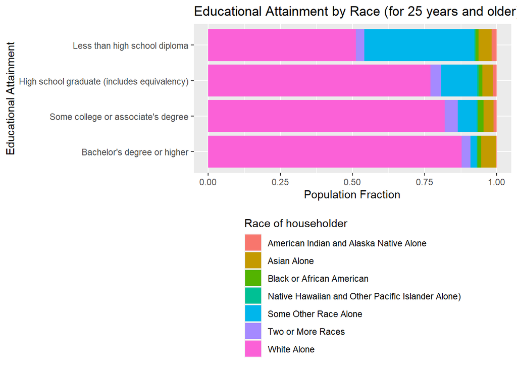

```r
#Filled bar graph
education_race %>%
  group_by(attainment, race) %>%
  summarize(estimate = sum(estimate)) %>%
  ggplot() +
  geom_bar(
    aes(
      x = attainment %>% factor(levels = rev(education_race$attainment[1:4])),
      y = estimate,
      fill = race
    ),
    stat = "identity",
    position = "fill"
  ) +
  labs(
    x = "Educational Attainment",
    y = "Population Fraction",
    title = "Educational Attainment by Race (for 25 years and older)",
    fill = "Race of householder"
  ) +
  coord_flip() +
  theme(
    legend.position = "bottom",
    legend.direction = "vertical"
  )
```

## I plotted the data in Sonoma county. The data does indicate a clear disparity in educational attainment skewed toward white folks. This was of course not very clear from the stacked bar graph because the population in the area is disproportionally white. However, when you plot the filled plot it becomes readily apparent. The disparity is increasing with level of education.

## Part 2: Fetch and process the PUMS data

```r
#temp <- tempfile()
#download.file("https://www2.census.gov/programs-surveys/acs/data/pums/2018/5-Year/csv_hca.zip",destfile = temp, mode = "wb")

#pums_hca_2018_5yr <- read_csv(unzip(temp,"psam_h06.csv"))

#unlink(temp)

library(tidycensus)

census_api_key("b1f6bae8291cffb092a4d2ad892d430db36d538f")

pums_vars_2018 <-
  pums_variables %>%
  filter(year == 2018, survey == "acs5")

pums_vars_2018_distinct_hh <-
  pums_vars_2018 %>%
  distinct(var_code, var_label, data_type, level) %>%
  filter(level == "housing")

ca_pums <- get_pums(
  variables = c(
    "PUMA",
    "NP",
    "ACCESS",
    "TEN",
    "SCHG"
  ),
  state = "CA",
  year = 2018,
  survey = "acs5",
  recode = T
)
```

[output not shown]

[output not shown]

```r
ca_pumas <-
  pumas("CA", cb = T, progress_bar = F)


bay_counties <-
  counties("CA", cb = T, progress_bar = F) %>%
  filter(NAME == "Sonoma")


bay_pumas <-
  ca_pumas %>%
  st_centroid() %>%
  .[bay_counties, ] %>%
  st_set_geometry(NULL) %>%
  left_join(ca_pumas %>% select(GEOID10)) %>%
  st_as_sf()

bay_pums <-
  ca_pums %>%
  filter(PUMA %in% bay_pumas$PUMACE10)
```

## Part 2: Percentage in Sonoma county

```r
bay_pums_example <-
  bay_pums %>%
  filter(!duplicated(SERIALNO)) %>%
  mutate(ACCESS = as.numeric(ACCESS),
         SCHG = as.numeric(SCHG),
         no_inter = ifelse(
           (ACCESS == 3) & (SCHG >= 2 & SCHG <= 14),
           PWGTP,
           0
         )) %>%
  mutate(ACCESS = as.numeric(ACCESS),
         SCHG = as.numeric(SCHG),
         inter = ifelse(
           (SCHG >= 2 & SCHG <= 14),
           PWGTP,
           0
         )) %>%
  group_by(PUMA) %>%
  left_join(
    bay_pumas %>%
      select(PUMACE10),
    by = c("PUMA" = "PUMACE10")
  )

#Calculating the quantity of interest
no_internet <- sum(bay_pums_example$no_inter, na.rm = T)
internet <- sum(bay_pums_example$inter, na.rm = T)
percentage <- 100*no_internet/(no_internet + internet)
print(percentage)
```

```
## [1] 11.75799
```

##Part 2: ~12% of K-12 students in Sonoma county live in households that do not have internet access. As far as using this data as a metric for distance learning, we are making the implicit assumption that not only is there internet in the household, we would need so assume that all of the children in the household have access (via proper devices) to that internet. There is also an assumption that the internet access has the bandwidth to support several parties streaming during the day.

```r
bay_county_names <-
  c(
    "Alameda",
    "Contra Costa",
    "Marin",
    "Napa",
    "San Francisco",
    "San Mateo",
    "Santa Clara",
    "Solano",
    "Sonoma"
  )

bay_counties <-
  counties("CA", cb = T, progress_bar = F) %>%
  filter(NAME %in% bay_county_names)


ca_pumas <-
  pumas("CA", cb = T, progress_bar = F)


bay_pumas <-
  ca_pumas %>%
  st_centroid() %>%
  .[bay_counties, ] %>%
  st_set_geometry(NULL) %>%
  left_join(ca_pumas %>% select(GEOID10)) %>%
  st_as_sf()

bay_pums <-
  ca_pums %>%
  filter(PUMA %in% bay_pumas$PUMACE10)
```

## Part 3: migration analysis

```r
library(tidyverse)
library(censusapi)


Sys.setenv(CENSUS_KEY="c8aa67e4086b4b5ce3a8717f59faa9a28f611dab")

acs_vars_2019_1yr <-
  listCensusMetadata(
    name = "2019/acs/acs1",
    type = "variables"
  )


sonoma_19 <-
  getCensus(
    name = "acs/acs1",
    vintage = 2019,
    region = "county:097",
    regionin = "state:06",
    vars = c("group(B07009)")
  ) %>%
  select(!c(GEO_ID,state,NAME) & !ends_with(c("EA","MA","M"))) %>%
  pivot_longer(
    ends_with("E"),
    names_to = "variable",
    values_to = "estimate"
  )%>%
  left_join(
    acs_vars_2019_1yr %>%
      select(name, label),
    by = c("variable" = "name")
  ) %>%
  select(-variable) %>%
  separate(
    label,
    into = c(NA,NA,"mobility","temp","attainment"),
    sep = "!!"
  ) %>%
  mutate(
    attainment = temp,
    mobility = ifelse(
      mobility %in% c("Same house 1 year ago:", "Moved within same county:"),
      "Here since last year",
      "Inflow"
    )
  ) %>%
  filter(!is.na(attainment)) %>%
  group_by(mobility, attainment) %>%
  summarize(estimate = sum(estimate))


#Data set 2
sonoma_lastyear <-
  getCensus(
    name = "acs/acs1",
    vintage = 2019,
    region = "county:097",
    regionin = "state:06",
    vars = c("group(B07409)")
  ) %>%
  select(!c(GEO_ID,state,NAME) & !ends_with(c("EA","MA","M"))) %>%
  pivot_longer(
    ends_with("E"),
    names_to = "variable",
    values_to = "estimate"
  ) %>%
  left_join(
    acs_vars_2019_1yr %>%
      select(name, label),
    by = c("variable" = "name")
  ) %>%
  select(-variable) %>%
  separate(
    label,
    into = c(NA,NA,"mobility","temp","attainment"),
    sep = "!!"
  ) %>%
  mutate(
    attainment = temp,
    mobility = ifelse(
      mobility %in% c("Same house:", "Moved within same county:"),
      "Here since last year",
      "Outflow"
    )
  ) %>%
  filter(!is.na(attainment)) %>%
  group_by(mobility, attainment) %>%
  summarize(estimate = sum(estimate))


#Determine total income
sonoma_18 <-
  getCensus(
    name = "acs/acs1",
    vintage = 2018,
    region = "county:097",
    regionin = "state:06",
    vars = c("group(B07009)")
  ) %>%
  select(!c(GEO_ID,state,NAME) & !ends_with(c("EA","MA","M"))) %>%
  pivot_longer(
    ends_with("E"),
    names_to = "variable",
    values_to = "estimate"
  ) %>%
  left_join(
    acs_vars_2019_1yr %>%
      select(name, label),
    by = c("variable" = "name")
  ) %>%
  select(-variable) %>%
  separate(
    label,
    into = c(NA,NA,"mobility","temp","attainment"),
    sep = "!!"
  ) %>%
  mutate(
    attainment = temp,
    mobility = "Here last year"
  ) %>%
  filter(!is.na(attainment)) %>%
  group_by(mobility, attainment) %>%
  summarize(estimate = sum(estimate))


#Bind data together and create pivot table
sonoma_flows_19 <-
  rbind(
    sonoma_18,
    sonoma_lastyear %>%
      filter(mobility == "Outflow"),
    sonoma_19 %>%
      filter(mobility == "Inflow"),
    sonoma_19 %>%
      group_by(attainment) %>%
      summarize(estimate = sum(estimate)) %>%
      mutate(mobility = "Here this year")
  ) %>%
  pivot_wider(
    names_from = mobility,
    values_from = estimate
  ) %>%
  mutate(
    `External net` = Inflow - Outflow,
    `Internal net` = `Here this year` - `Here last year` - `External net`,
  ) %>%
  select(
    `Attainment tier` = attainment,
    `Internal net`,
    `External net`,
    `Here last year`,
    `Here this year`,
    Outflow,
    Inflow
  )

sonoma_flows_19
```

```
## # A tibble: 5 x 7
##   `Attainment tie~ `Internal net` `External net` `Here last year`
##   <chr>                     <dbl>          <dbl>            <dbl>
## 1 Bachelor's degr~           5024           -397            79289
## 2 Graduate or pro~           -821            308            51071
## 3 High school gra~           2372            -61            65771
## 4 Less than high ~          -3228            -62            40409
## 5 Some college or~          -5089            201           124337
## # ... with 3 more variables: `Here this year` <dbl>, Outflow <dbl>,
## #   Inflow <dbl>
```

## Looking at the data in the table, we can observe that we have an in flow of folks with a graduate or professional degree into the area. By comparison we have flux out of folks with less than a high school graduate degree